# Isotopic abundances and variations in nature

Dr. Ahmad Redaa

2024-08-25

# Introduction

## Natural Abundance of Isotopes

- **Definition:** Relative amounts of each isotope of an element found in nature, expressed as percentages.
- **Example 1: Carbon**
  - Carbon-12 (⁶C¹²): ~98.9%
  - Carbon-13 (⁶C¹³): ~1.1%
- **Example 2: Hydrogen**
  - Protium (¹H¹): ~99.98%
  - Deuterium (¹H²): ~0.02%
  - Tritium (¹H³): Trace amounts

# The Origin of Elements

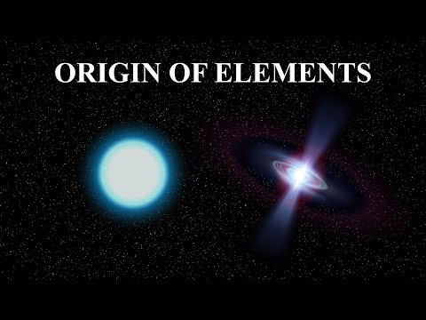

Click to watch the video

# Factors Controlling Natural Abundance of Isotopes

- **Nuclear Stability**: Stable isotopes are more abundant.
- **Production Mechanisms**: the production mechanisms influence isotopes relative abundances in nature (i.e., Stellar Production, Lighter isotopes are often more abundant than heavier isotopes).
- **Decay Rates**: Isotopes with shorter half-lives decay faster and they are less aboundance in nature.
- **Cosmic and Geological Processes**: Alterations from events and processes make some isotopes less aboundace compare to others..
- **Chemical and Physical Processes**: Isotopic fractionation affacts the abundance of isotopes.
- **Atomic Number**: Affects stability and abundance; higher atomic numbers often lead to more radioactive isotopes.

# Atomic number vs abundances of the elements

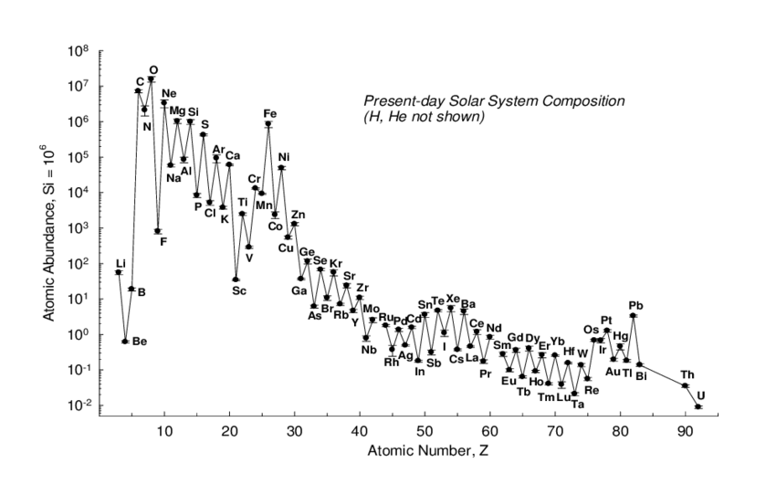

Abundances of the elements as a function of atomic number, (Source: [Lodders, K. (2010)](https://doi.org/10.1007/978-3-642-10352-0_8))

# Nuclear Stability

- **Binding Energy**: Energy required to hold nucleons together, higher binding energies increase stability.
- **Neutron-to-Proton Ratio**: Balance between protons and neutrons affects stability.
- **Magic Numbers**: 2, 8, 20, 28, 50, 82, and 126.

# Example: impact of Neutron-to-Proton Ratio on the abundance

[figure not shown]

Natural Abundance of Carbon Isotopes with Neutron-Proton Balance

# Assignment

**Check the Blackboard**

**Due date:** 31/08/2024